# Lab 4: Two-way Between Subjects ANOVA

## Introduction

This tutorial will learn how to run two-way between-subjects ANOVA from Lab 1. We will calculate descriptive statistics, check ANOVA assumptions, calculate ANOVA, effects, and marginal means, and identify any interactions.

We will use data from your textbook (see [‘Support Materials’ on the textbook webpage](https://www.routledge.com/Design-and-Analysis-in-Educational-Research-ANOVA-Designs-in-SPSS/Strunk-Mwavita/p/book/9781138361164)) (Perez, Schanding, and Dao, 2013). For your Lab 4 assignment, you will use the data provided on Canvas.

First, load necessary packages:

```r
needs(tidyverse, rio, here, knitr, kableExtra, misty, janitor, rstatix, psych, misty)
```

## Describe Data

Next, we will read in the data, similar to the process in your previous labs.

```r
df <- misty::read.sav(here("kamden-mwavita_data/factorial ANOVA - Perez, Schanding, and Dao.sav"), use.value.labels = TRUE) %>%
  clean_names()
```

Now, let’s learn a little more about this dataset. View the structure of the dataset and then the top 5 rows using the code below.

**Quick side note:** If you are ever confused about what a function does, how it works, or what arguments it can take, I recommend using R’s `?` feature. For example, in the console, I could type `?head()` and learn more about the `head()` function and its usage. Here, you can see that you can specify how many rows you want to show up (we’ll try this below). This `?` feature might be especially helpful as you’re using more complicated functions, like `geom_boxplot()`, and you are trying to figure out how to put a title your plot.

```r
str(df)
```

```
## 'data.frame':    186 obs. of  3 variables:
##  $ seriousness  : num  4.84 4.34 5.17 5.08 4.51 ...
##   ..- attr(*, "label")= chr "Seriousness Rating"
##  $ scenario_type: Factor w/ 2 levels "LGBTQ or gender noncomforming",..: 1 1 1 1 1 1 1 1 1 1 ...
##  $ bullying_type: Factor w/ 3 levels "Verbal","Relational",..: 1 1 1 1 1 1 1 1 1 1 ...
```

```r
head(df, n=3)
```

```
##   seriousness                 scenario_type bullying_type
## 1    4.838513 LGBTQ or gender noncomforming        Verbal
## 2    4.338410 LGBTQ or gender noncomforming        Verbal
## 3    5.167691 LGBTQ or gender noncomforming        Verbal
```

Notice for this data, there are two variables, `scenario_type` and `bullying_type`, that are both factors. Scenario type has two levels: 1) LGBTQ or gender nonconforming, and 2) Non-LGBTQ/gender nonconforming. Bullying type has three levels: 1) Verbal, 2) Relational, and 3) Physical. The `table` function is useful, especially for categorical variables, to break down the distribution and see how many of each category are represented in the data.

```r
table(df$scenario_type)
```

```
##
##  LGBTQ or gender noncomforming Non-LGBTQ/gender nonconforming
##                             97                             89
```

```r
table(df$bullying_type)
```

```
##
##     Verbal Relational   Physical
##         62         64         60
```

Now, let’s view a summary table of the data with both variables. The code below helps you create a frequency table. You group by the two variables you want to see, summarize n (this is just a row count), and then you pick a variable to be at the top. You put this variable in the spread function.

```r
df %>%
  group_by(scenario_type, bullying_type) %>%
  summarise(n = n()) %>% #new column "n" = row count of each factor grouping
  spread(bullying_type, n) # rows "spread" across the top
```

```
## # A tibble: 2 × 4
## # Groups:   scenario_type [2]
##   scenario_type                  Verbal Relational Physical
##   <fct>                           <int>      <int>    <int>
## 1 LGBTQ or gender noncomforming      32         33       32
## 2 Non-LGBTQ/gender nonconforming     30         31       28
```

Then check the overall descriptive statistics.

```r
describe(df)
```

```
##                vars   n mean   sd median trimmed  mad  min  max range  skew
## seriousness       1 186 4.52 0.66   4.62    4.56 0.58 2.29 6.79   4.5 -0.55
## scenario_type*    2 186 1.48 0.50   1.00    1.47 0.00 1.00 2.00   1.0  0.09
## bullying_type*    3 186 1.99 0.81   2.00    1.99 1.48 1.00 3.00   2.0  0.02
##                kurtosis   se
## seriousness        1.18 0.05
## scenario_type*    -2.00 0.04
## bullying_type*    -1.49 0.06
```

If we want to check descriptives for each level, we can use the `describeBy()` function. We can then look at how the seriousness scores vary for bullying type levels and for scenario type levels. You’ll find the mean and standard deviations for each group below.

```r
#Output for each level - bullying type
describeBy(x = df$seriousness, group = df$bullying_type,
             mat = TRUE, data = df)
```

```
##     item     group1 vars  n     mean        sd   median  trimmed       mad
## X11    1     Verbal    1 62 4.519355 0.6032966 4.635448 4.562630 0.5622137
## X12    2 Relational    1 64 4.345156 0.6428261 4.351083 4.396332 0.7274690
## X13    3   Physical    1 60 4.710000 0.6774654 4.723787 4.727624 0.4869695
##          min      max    range       skew     kurtosis         se
## X11 2.850223 5.857973 3.007751 -0.5707928  0.007586576 0.07661875
## X12 2.650140 5.463012 2.812872 -0.6499143 -0.196428287 0.08035326
## X13 2.290972 6.792736 4.501765 -0.6127808  3.187425976 0.08746040
```

```r
#Output for each level - scenario type
describeBy(x = df$seriousness, group = df$scenario_type,
             mat = TRUE, data = df)
```

```
##     item                         group1 vars  n     mean        sd   median
## X11    1  LGBTQ or gender noncomforming    1 97 4.676495 0.6062204 4.700279
## X12    2 Non-LGBTQ/gender nonconforming    1 89 4.351348 0.6678403 4.426783
##      trimmed       mad      min      max    range       skew   kurtosis
## X11 4.693582 0.5067830 2.290972 6.792736 4.501765 -0.5308542  3.2608225
## X12 4.394298 0.6767025 2.650140 5.857973 3.207833 -0.5139067 -0.3263466
##             se
## X11 0.06155236
## X12 0.07079093
```

Using the code above, report the mean/sd and describe the distributions for the levels of each variable.

### Boxplots

The boxplot creation uses the same general code from before, using the `ggplot()` and `geom_boxplot()` functions. The main substantive change is, besides including the x value of `scenario_type` and y value of `seriousness`, that we also include `fill = bullying_type` to show visually how different bullying levels would vary across scenario types. The other code edits are just additional elements to make the plot a bit more visually appealing.

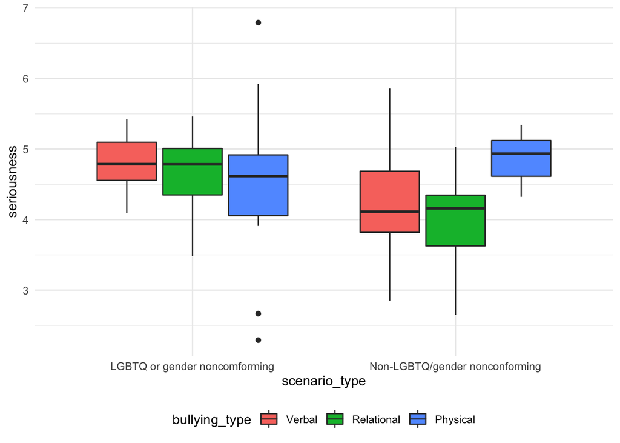

```r
scenario_plot <- df %>%
  ggplot(aes(x = scenario_type, y = seriousness, fill = bullying_type)) +
  geom_boxplot() +
  theme_minimal() +
  theme(legend.position="bottom")

scenario_plot
```

You code also run the boxplot the other way

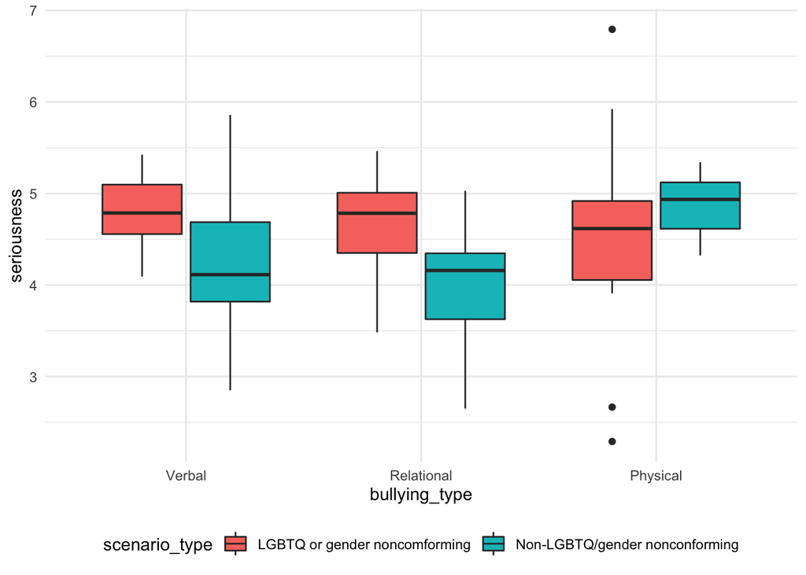

```r
bullying_plot <- df %>%
  ggplot(aes(x = bullying_type, y = seriousness, fill = scenario_type)) +
  geom_boxplot() +
  theme_minimal() +
  theme(legend.position="bottom")

bullying_plot
```

If you want to, you can display them side-by-side using the code below. In this case, I would just keep them separate, since some of the words cut out if you use the code here.

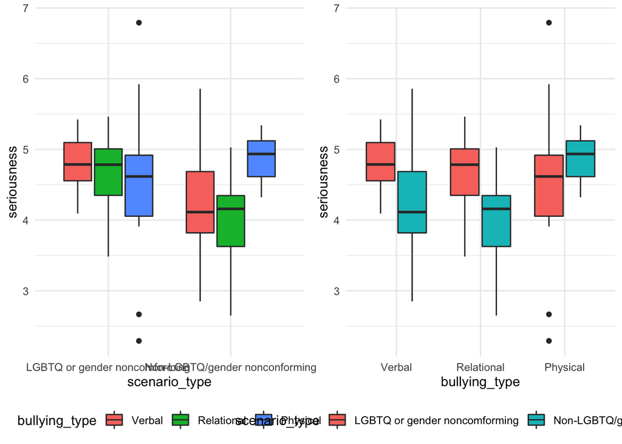

```r
gridExtra::grid.arrange(scenario_plot, bullying_plot, nrow = 1)
```

Either way, include your interpretations of the boxplots here. Comment on what you see. What differences do you notice between the groups? Comment on how these differences might affect what you might expect from your analysis.

## Checking assumptions

First, check homogeneity of variance:

```r
car::leveneTest(seriousness ~ bullying_type*scenario_type, data = df, center = "mean")
```

```
## Levene's Test for Homogeneity of Variance (center = "mean")
##        Df F value    Pr(>F)
## group   5  5.1821 0.0001814 ***
##       180
## ---
## Signif. codes:  0 '***' 0.001 '**' 0.01 '*' 0.05 '.' 0.1 ' ' 1
```

The p-value of 0.0001 is significant, suggesting that the error variance around the mean is likely not equal across groups. Additional corrections would be needed in this case for one-way ANOVA (i.e. Games-Howell), but we will use Tukey for two-way ANOVA since Games-Howell for two-way does not exist on R.

We will also assume observations to be independent here (see [Perez, Schanding, and Dao, 2013](https://www.ojp.gov/ncjrs/virtual-library/abstracts/educators-perceptions-addressing-bullying-lgbtqgender-nonconforming) for more details).

### Two-way ANOVA

Since you have a two-way ANOVA, both variables, as well as their interaction, should be accounted for in the model. Still keep your dependent variable to the left of the ~, but this time include each variable and the interaction between each variable (variable_a:variable_b) also into the model. See below.

```r
m1 <- anova_test(df, formula = seriousness ~ bullying_type + scenario_type + bullying_type:scenario_type,
                 detailed = TRUE, type = 3, effect.size = "pes")
```

```
## Coefficient covariances computed by hccm()
```

```r
m1
```

```
## ANOVA Table (type III tests)
##
##                        Effect      SSn    SSd DFn DFd         F         p p<.05
## 1                 (Intercept) 3791.880 62.008   1 180 11007.334 2.32e-163     *
## 2               bullying_type    4.582 62.008   2 180     6.651  2.00e-03     *
## 3               scenario_type    4.456 62.008   1 180    12.934  4.17e-04     *
## 4 bullying_type:scenario_type    8.528 62.008   2 180    12.377  9.19e-06     *
##     pes
## 1 0.984
## 2 0.069
## 3 0.067
## 4 0.121
```

From these results, we see that the effect of bullying type, scenario type, and the interaction of bullying type and scenario type are all significant at an alpha of 0.05. Since the interaction is significant, that is the main focus for the analysis here and beyond. We will not focus on the main effects. If the interaction were not significant, then we would have focused on interpreting the main effects.

#### Effect size with Omega

Let’s calculate effect size with Omega. Partial eta squared is already given in the ANOVA output. We need the following values (see ANOVA output for the corresponding values from the interaction):

- dfn = 2
- dfd = 180
- Fvalue = 12.377
- n = 186
- a = .05

Now, just plug them in. Refer to previous labs/notes for interpretations.

```r
needs(MOTE)
omega.F(dfm = 2, dfe = 180,
      Fvalue = 12.377, n = 186, a = .05)
```

```
## $omega
## [1] 0.1089991
##
## $omegalow
## [1] 0.03339479
##
## $omegahigh
## [1] 0.1996924
##
## $dfm
## [1] 2
##
## $dfe
## [1] 180
##
## $F
## [1] 12.377
##
## $p
## [1] 9.196232e-06
##
## $estimate
## [1] "$\\omega^2$ = 0.11, 95\\% CI [0.03, 0.20]"
##
## $statistic
## [1] "$F$(2, 180) = 12.38, $p$ < .001"
```

Next, we examine simple effects.

#### Simple effects

Note: For two-way post-hoc comparisons, go ahead and use Tukey, regardless of which way your assumptions fall. Games-Howell does not work for two-way ANOVAs. This way, you can pairwise compare main and simple effects.

The estimate in the code below is calculated by subtracting Group 1 from Group 2 (Group 2 - Group 1 = estimate).

**Quick note:** it is important that you look at the variables that change only one at a time. For example, comparing physical & LGBTQ with relational & non-LGBTQ will not really tell you much, since the comparison is not truly pairwise. In R, the code below just gives you all possible pairs. It is up to you to go through them and interpret what actually makes sense in your case. I’ll walk through my process below.

```r
rstatix::tukey_hsd(df, seriousness ~ bullying_type*scenario_type) #main and simple effects
```

```
## # A tibble: 19 × 9
##    term             group1 group2 null.value estimate conf.low conf.high   p.adj
##  * <chr>            <chr>  <chr>       <dbl>    <dbl>    <dbl>     <dbl>   <dbl>
##  1 bullying_type    Verbal Relat…          0  -0.174   -0.421     0.0730 2.21e-1
##  2 bullying_type    Verbal Physi…          0   0.191   -0.0605    0.442  1.75e-1
##  3 bullying_type    Relat… Physi…          0   0.365    0.116     0.614  1.95e-3
##  4 scenario_type    LGBTQ… Non-L…          0  -0.321   -0.491    -0.151  2.62e-4
##  5 bullying_type:s… Verba… Relat…          0  -0.140   -0.559     0.279  9.29e-1
##  6 bullying_type:s… Verba… Physi…          0  -0.230   -0.653     0.193  6.21e-1
##  7 bullying_type:s… Verba… Verba…          0  -0.580   -1.01     -0.150  1.94e-3
##  8 bullying_type:s… Verba… Relat…          0  -0.790   -1.22     -0.364  4.09e-6
##  9 bullying_type:s… Verba… Physi…          0   0.0700  -0.368     0.508  9.97e-1
## 10 bullying_type:s… Relat… Physi…          0  -0.0900  -0.509     0.329  9.9 e-1
## 11 bullying_type:s… Relat… Verba…          0  -0.440   -0.867    -0.0135 3.89e-2
## 12 bullying_type:s… Relat… Relat…          0  -0.650   -1.07     -0.227  2.36e-4
## 13 bullying_type:s… Relat… Physi…          0   0.210   -0.224     0.644  7.32e-1
## 14 bullying_type:s… Physi… Verba…          0  -0.350   -0.780     0.0797 1.81e-1
## 15 bullying_type:s… Physi… Relat…          0  -0.560   -0.986    -0.134  2.82e-3
## 16 bullying_type:s… Physi… Physi…          0   0.300   -0.138     0.738  3.61e-1
## 17 bullying_type:s… Verba… Relat…          0  -0.210   -0.643     0.223  7.29e-1
## 18 bullying_type:s… Verba… Physi…          0   0.650    0.206     1.09   5.58e-4
## 19 bullying_type:s… Relat… Physi…          0   0.860    0.419     1.30   1.06e-6
## # … with 1 more variable: p.adj.signif <chr>
```

The following differences are significant for **main effects** (rows 1-4):

- bullying type: relational vs. physical (row 3)
- scenario type: LGBTQ or gender nonconforming vs. Non-LGBTQ/gender nonconforming (row 4)

Notice that other rows may have been significant, but they were not included in my selections since two variables changed at a time.

In your interpretations, you can **ignore the differences in main effects, since the interaction is signficant.**

### Marginal Means

While the Tukey test above tells us about how the means are (or are not) different from each other, the test doesn’t actually tell us *what the means are.* The code below helps you get the actual marginal means, along with their standard errors and confidence intervals. To do this, you can group by one variable (I chose `bullying_type` here, but you could have chosen the other one), and then you regress on the other variable (I did used `scenario_type` as the x, with `seriousness` as the dependent variable as usual). The rest of the code helps you get the values in an easy-to-read format.

```r
means <- df %>%
  group_by(bullying_type) %>%
  emmeans_test(seriousness ~ scenario_type, p.adjust.method = "holm", detailed = TRUE)
rmarkdown::paged_table(means) #for mean differences and significance tests
```

|  | bullying_type | term | .y. | group1 | group2 | null.value | estimate | se | df | conf.low | conf.high | statistic | p | p.adj | p.adj.signif |
| --- | --- | --- | --- | --- | --- | --- | --- | --- | --- | --- | --- | --- | --- | --- | --- |
| 1 | Physical | scenario_type | seriousness | LGBTQ or gender noncomforming | Non | 0 | -0.30 | 0.1518825 | 180 | -0.5996993 | -0.0003007061 | -1.975211 | 4.977301e-02 | 4.977301e-02 | * |
| 2 | Relational | scenario_type | seriousness | LGBTQ or gender noncomforming | Non | 0 | 0.65 | 0.1468042 | 180 | 0.3603215 | 0.9396785043 | 4.427667 | 1.648829e-05 | 1.648829e-05 | **** |
| 3 | Verbal | scenario_type | seriousness | LGBTQ or gender noncomforming | Non | 0 | 0.58 | 0.1491580 | 180 | 0.2856769 | 0.8743230854 | 3.888495 | 1.417471e-04 | 1.417471e-04 | *** |

```r
#To get actual marginal means
rmarkdown::paged_table(
  get_emmeans(means)
)
```

| bullying_type | scenario_type | emmean | se | df | conf.low | conf.high | method |
| --- | --- | --- | --- | --- | --- | --- | --- |
| Verbal | LGBTQ or gender noncomforming | 4.80 | 0.1037555 | 180 | 4.595266 | 5.004734 | Emmeans test |
| Verbal | Non-LGBTQ/gender nonconforming | 4.22 | 0.1071582 | 180 | 4.008552 | 4.431448 | Emmeans test |
| Relational | LGBTQ or gender noncomforming | 4.66 | 0.1021714 | 180 | 4.458392 | 4.861608 | Emmeans test |
| Relational | Non-LGBTQ/gender nonconforming | 4.01 | 0.1054157 | 180 | 3.801990 | 4.218010 | Emmeans test |
| Physical | LGBTQ or gender noncomforming | 4.57 | 0.1037555 | 180 | 4.365266 | 4.774734 | Emmeans test |
| Physical | Non-LGBTQ/gender nonconforming | 4.87 | 0.1109193 | 180 | 4.651131 | 5.088869 | Emmeans test |

#### Univariate Comparisons

If needed, you can also run univariate comparisons, looking at one variable at a time. This may not be as useful if you have interactions that are significant.

```r
model <- lm(seriousness ~ bullying_type + scenario_type + bullying_type:scenario_type, data = df)

df %>%
  group_by(scenario_type) %>%
  anova_test(seriousness ~ bullying_type, error = model)
```

```
## Coefficient covariances computed by hccm()
## Coefficient covariances computed by hccm()
```

```
## # A tibble: 2 × 8
##   scenario_type                  Effect    DFn   DFd     F       p `p<.05`   ges
## * <fct>                          <chr>   <dbl> <dbl> <dbl>   <dbl> <chr>   <dbl>
## 1 LGBTQ or gender noncomforming  bullyi…     2   180  1.25 2.89e-1 ""      0.014
## 2 Non-LGBTQ/gender nonconforming bullyi…     2   180 16.9  1.84e-7 "*"     0.158
```

```r
df %>%
  group_by(bullying_type) %>%
  anova_test(seriousness ~ scenario_type, error = model)
```

```
## Coefficient covariances computed by hccm()
## Coefficient covariances computed by hccm()
## Coefficient covariances computed by hccm()
```

```
## # A tibble: 3 × 8
##   bullying_type Effect          DFn   DFd     F         p `p<.05`   ges
## * <fct>         <chr>         <dbl> <dbl> <dbl>     <dbl> <chr>   <dbl>
## 1 Verbal        scenario_type     1   180 15.1  0.000142  *       0.077
## 2 Relational    scenario_type     1   180 19.6  0.0000165 *       0.098
## 3 Physical      scenario_type     1   180  3.90 0.05      *       0.021
```

### Interaction Plots

Finally, while all the tables and analyses are important to go through and understand, in a paper, what might be the most helpful is an actual visualization of the analysis. To illustrate interactions, the best way is through an interaction plot, where you put in each of the variables (one as the `x.factor` and the other as the `trace.factor`) in relation to your outcome variable (i.e. `seriousness`). See code below.

One option:

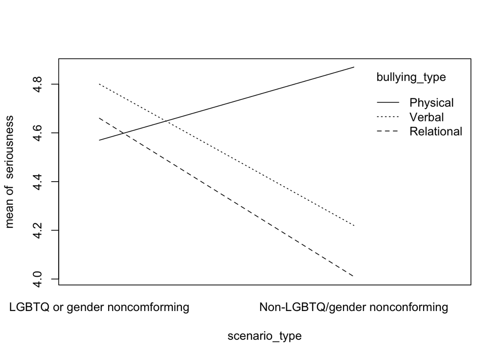

```r
with(df, {
interaction.plot(x.factor = scenario_type,
                 trace.factor = bullying_type,
                 response = seriousness,
                 type = "l")
})
```

Another option:

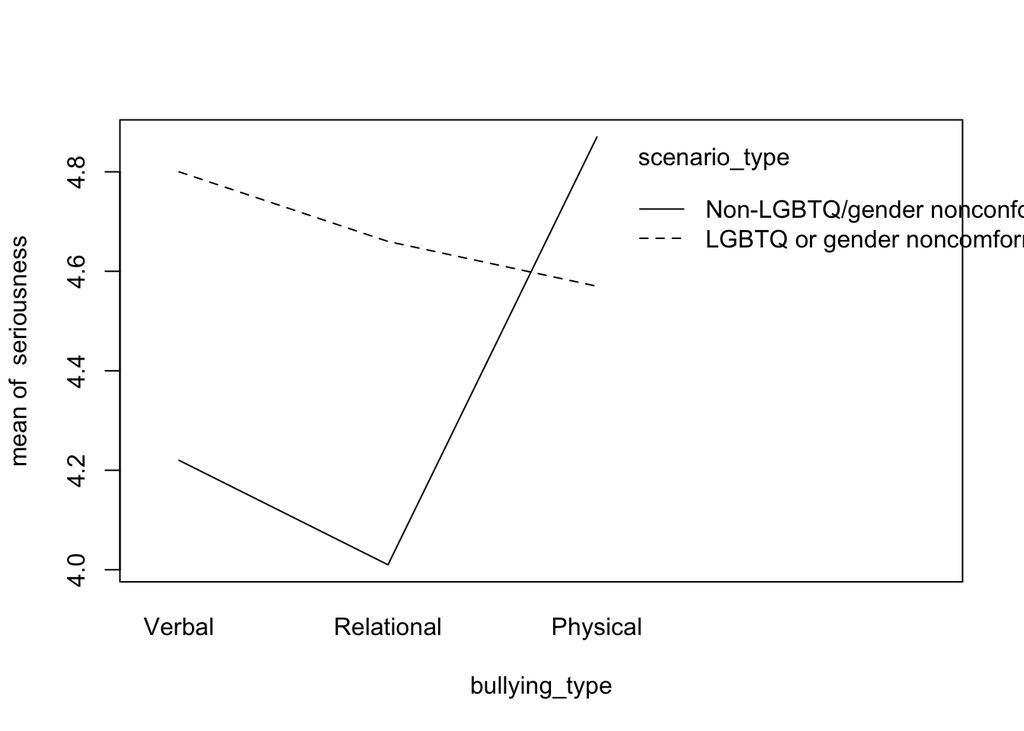

```r
with(df, {
interaction.plot(x.factor = bullying_type,
                 trace.factor = scenario_type,
                 response = seriousness,
                 type = "l")
})
```

Pick whichever option makes the most sense for your data.